# Lab 8A: ML in Practice (Easy)

### 1. Explore the Data

1. Set working directory

```r
setwd("C:/Workshop/Data")
```

2. Read CSV file

```r
raw <- read.csv("Titanic.csv")
```

3. Peek at the data

```r
head(raw)
```

```
##   pclass survived                                            name    sex
## 1      1        1                   Allen, Miss. Elisabeth Walton female
## 2      1        1                  Allison, Master. Hudson Trevor   male
## 3      1        0                    Allison, Miss. Helen Loraine female
## 4      1        0            Allison, Mr. Hudson Joshua Creighton   male
## 5      1        0 Allison, Mrs. Hudson J C (Bessie Waldo Daniels) female
## 6      1        1                             Anderson, Mr. Harry   male
##       age sibsp parch ticket     fare   cabin embarked boat body
## 1 29.0000     0     0  24160 211.3375      B5        S    2   NA
## 2  0.9167     1     2 113781 151.5500 C22 C26        S   11   NA
## 3  2.0000     1     2 113781 151.5500 C22 C26        S        NA
## 4 30.0000     1     2 113781 151.5500 C22 C26        S       135
## 5 25.0000     1     2 113781 151.5500 C22 C26        S        NA
## 6 48.0000     0     0  19952  26.5500     E12        S    3   NA
##                         home.dest
## 1                    St Louis, MO
## 2 Montreal, PQ / Chesterville, ON
## 3 Montreal, PQ / Chesterville, ON
## 4 Montreal, PQ / Chesterville, ON
## 5 Montreal, PQ / Chesterville, ON
## 6                    New York, NY
```

4. Summarize the data set

```r
summary(raw)
```

```
##      pclass         survived                                   name
##  Min.   :1.000   Min.   :0.000   Connolly, Miss. Kate            :   2
##  1st Qu.:2.000   1st Qu.:0.000   Kelly, Mr. James                :   2
##  Median :3.000   Median :0.000   Abbing, Mr. Anthony             :   1
##  Mean   :2.295   Mean   :0.382   Abbott, Master. Eugene Joseph   :   1
##  3rd Qu.:3.000   3rd Qu.:1.000   Abbott, Mr. Rossmore Edward     :   1
##  Max.   :3.000   Max.   :1.000   Abbott, Mrs. Stanton (Rosa Hunt):   1
##                                  (Other)                         :1301
##      sex           age              sibsp            parch
##  female:466   Min.   : 0.1667   Min.   :0.0000   Min.   :0.000
##  male  :843   1st Qu.:21.0000   1st Qu.:0.0000   1st Qu.:0.000
##               Median :28.0000   Median :0.0000   Median :0.000
##               Mean   :29.8811   Mean   :0.4989   Mean   :0.385
##               3rd Qu.:39.0000   3rd Qu.:1.0000   3rd Qu.:0.000
##               Max.   :80.0000   Max.   :8.0000   Max.   :9.000
##               NA's   :263
##       ticket          fare                     cabin      embarked
##  CA. 2343:  11   Min.   :  0.000                  :1014    :  2
##  1601    :   8   1st Qu.:  7.896   C23 C25 C27    :   6   C:270
##  CA 2144 :   8   Median : 14.454   B57 B59 B63 B66:   5   Q:123
##  3101295 :   7   Mean   : 33.295   G6             :   5   S:914
##  347077  :   7   3rd Qu.: 31.275   B96 B98        :   4
##  347082  :   7   Max.   :512.329   C22 C26        :   4
##  (Other) :1261   NA's   :1         (Other)        : 271
##       boat          body                      home.dest
##         :823   Min.   :  1.0                       :564
##  13     : 39   1st Qu.: 72.0   New York, NY        : 64
##  C      : 38   Median :155.0   London              : 14
##  15     : 37   Mean   :160.8   Montreal, PQ        : 10
##  14     : 33   3rd Qu.:256.0   Cornwall / Akron, OH:  9
##  4      : 31   Max.   :328.0   Paris, France       :  9
##  (Other):308   NA's   :1188    (Other)             :639
```

5. Visualize the data set

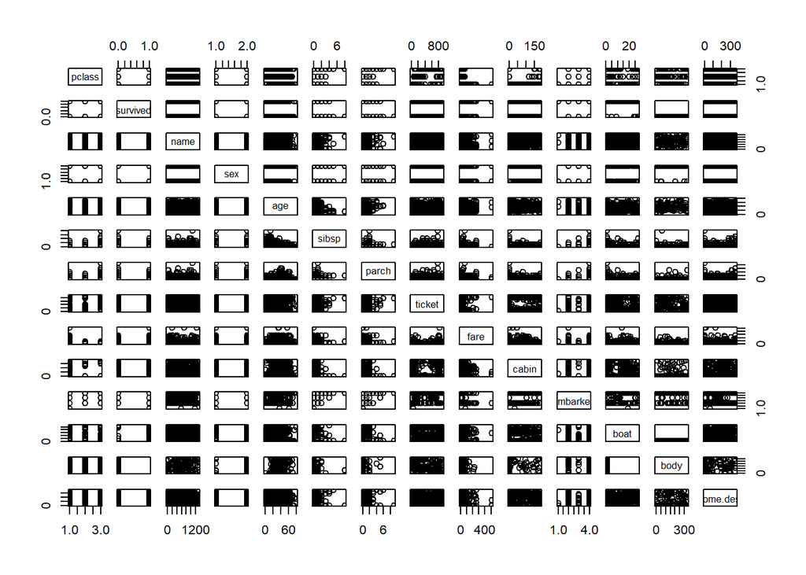

```r
plot(raw)
```

6. Load the corrgram package

```r
library(corrgram)
```

7. Visualize the correlations

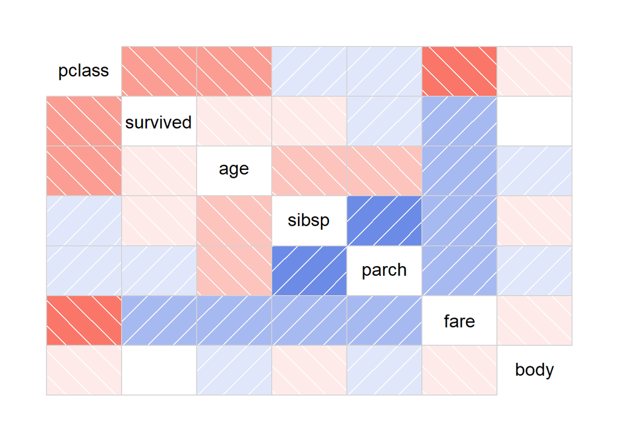

```r
corrgram(raw)
```

```r
sum(is.na(raw))
```

```
## [1] 1452
```

9. Load the dplyr package

```r
library(dplyr)
```

10. Transform, clean, engineer, and select features

```r
clean <- raw %>%
  mutate(age = ifelse(is.na(age), mean(na.omit(age)), age)) %>%
  mutate(family = sibsp + parch) %>%
  mutate(survived = as.factor(ifelse(survived == 0, "No", "Yes"))) %>%
  select(
    Class = pclass,
    Sex = sex,
    Age = age,
    Family = family,
    Survived = survived) %>%
  as.data.frame()
```

### 2. Create Training and Test Set

1. Load the caret package

```r
library(caret)
```

2. Set the seed to 42 to make randomness reproducable.

```r
set.seed(42)
```

3. Create row indexes for the training set

```r
indexes <- createDataPartition(
  clean$Survived,
  p = .8,
  list = FALSE,
  times = 1)
```

4. Create the training set using the row indexes

```r
train <- clean[indexes, ]
```

5. Create the test set using the remaining rows

```r
test <- clean[-indexes, ]
```

6. Specify center and scale as preprocessing steps

```r
preProcess <- c("center", "scale")
```

7. Specify training control parameters

```r
control <- trainControl(
  method = "cv",
  number = 10)
```

### 3. Train KNN Models

1. Train k-nearest neighbor models

```r
knnModel <- train(
  form = Survived ~ .,
  data = train,
  method = "knn",
  preProcess = preProcess,
  trControl = control,
  tuneLength = 5,
  metric = "Accuracy")
```

2. Display model details

```r
print(knnModel)
```

```
## k-Nearest Neighbors
##
## 1048 samples
##    4 predictor
##    2 classes: 'No', 'Yes'
##
## Pre-processing: centered (4), scaled (4)
## Resampling: Cross-Validated (10 fold)
## Summary of sample sizes: 943, 943, 943, 944, 943, 943, ...
## Resampling results across tuning parameters:
##
##   k   Accuracy   Kappa
##    5  0.8015842  0.5754371
##    7  0.7929762  0.5562429
##    9  0.8034890  0.5779054
##   11  0.8120788  0.5945939
##   13  0.8120696  0.5931258
##
## Accuracy was used to select the optimal model using the largest value.
## The final value used for the model was k = 11.
```

3. Plot model accuracy

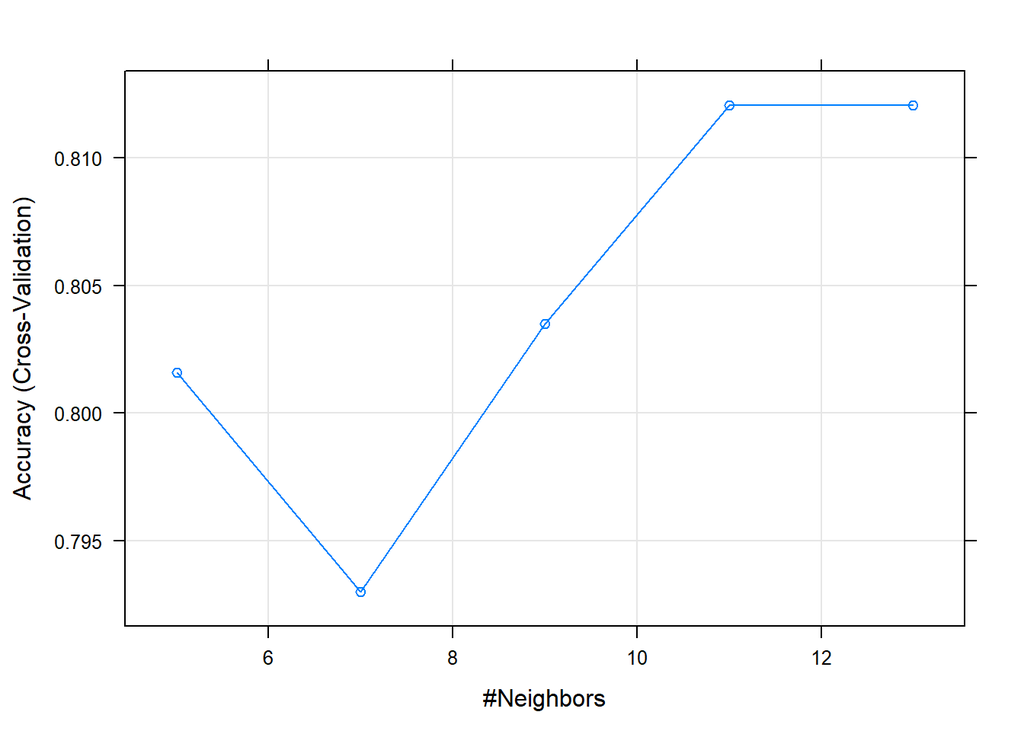

```r
plot(knnModel)
```

### 4. Train Decision Tree Models

1. Train decision tree models

```r
treeModel <- train(
  form = Survived ~ .,
  data = train,
  method = "rpart",
  preProcess = preProcess,
  trControl = control,
  tuneLength = 5,
  metric = "Accuracy")
```

2. Display model summary

```r
print(treeModel)
```

```
## CART
##
## 1048 samples
##    4 predictor
##    2 classes: 'No', 'Yes'
##
## Pre-processing: centered (4), scaled (4)
## Resampling: Cross-Validated (10 fold)
## Summary of sample sizes: 943, 943, 943, 943, 943, 944, ...
## Resampling results across tuning parameters:
##
##   cp        Accuracy   Kappa
##   0.004375  0.8053388  0.5776352
##   0.005000  0.8072619  0.5811883
##   0.021250  0.8005861  0.5695910
##   0.023750  0.7871978  0.5433680
##   0.450000  0.6727473  0.1890019
##
## Accuracy was used to select the optimal model using the largest value.
## The final value used for the model was cp = 0.005.
```

3. Plot model accuracy

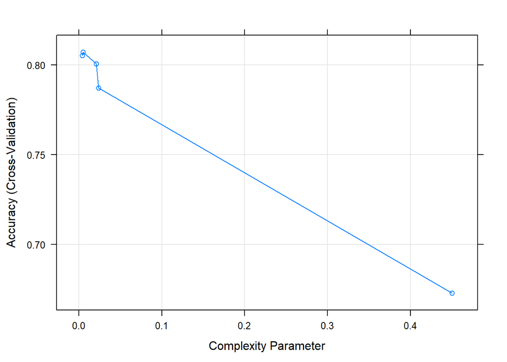

```r
plot(treeModel)
```

### 5. Train Neural Network Models

1. Specify hyperparameter-tuning grid

```r
neuralTuneGrid <- data.frame(
  size = c(3, 4, 5, 3, 4, 5, 3, 4, 5),
  decay = c(0.1, 0.1, 0.1, 0.01, 0.01, 0.01, 0.001, 0.001, 0.001))
```

2. Train neural network models

```r
neuralModel <- train(
  form = Survived ~ .,
  data = train,
  method = "nnet",
  preProcess = preProcess,
  trControl = control,
  tuneGrid = neuralTuneGrid)
```

3. Display model summary

```r
print(neuralModel)
```

```
## Neural Network
##
## 1048 samples
##    4 predictor
##    2 classes: 'No', 'Yes'
##
## Pre-processing: centered (4), scaled (4)
## Resampling: Cross-Validated (10 fold)
## Summary of sample sizes: 943, 943, 943, 943, 943, 943, ...
## Resampling results across tuning parameters:
##
##   size  decay  Accuracy   Kappa
##   3     0.001  0.8053388  0.5789952
##   3     0.010  0.8139469  0.5966001
##   3     0.100  0.8158700  0.5994007
##   4     0.001  0.8129945  0.5935100
##   4     0.010  0.8168315  0.6029929
##   4     0.100  0.8158700  0.5968726
##   5     0.001  0.8196886  0.6092592
##   5     0.010  0.8129945  0.5953079
##   5     0.100  0.8177564  0.6022955
##
## Accuracy was used to select the optimal model using the largest value.
## The final values used for the model were size = 5 and decay = 0.001.
```

4 Plot model accuracy

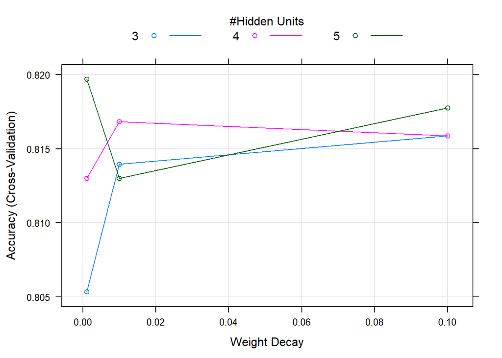

```r
plot(neuralModel)
```

### 6. Evaluate the Models

1. Combine results

```r
results <- resamples(list(
  knn = knnModel,
  tree = treeModel,
  nnet = neuralModel))
```

2. Summarize results

```r
summary(results)
```

```
##
## Call:
## summary.resamples(object = results)
##
## Models: knn, tree, nnet
## Number of resamples: 10
##
## Accuracy
##           Min.   1st Qu.    Median      Mean   3rd Qu.      Max. NA's
## knn  0.7428571 0.8023810 0.8142857 0.8120788 0.8281593 0.8557692    0
## tree 0.7238095 0.7852335 0.8229853 0.8072619 0.8357143 0.8476190    0
## nnet 0.7714286 0.8081502 0.8238095 0.8196886 0.8380952 0.8653846    0
##
## Kappa
##           Min.   1st Qu.    Median      Mean   3rd Qu.      Max. NA's
## knn  0.4521739 0.5805516 0.5956140 0.5945939 0.6252555 0.6849758    0
## tree 0.3817259 0.5313906 0.6191558 0.5811883 0.6373072 0.6673267    0
## nnet 0.5058824 0.5790588 0.6090769 0.6092592 0.6465084 0.7156250    0
```

3. Create a dot plot to compare top models

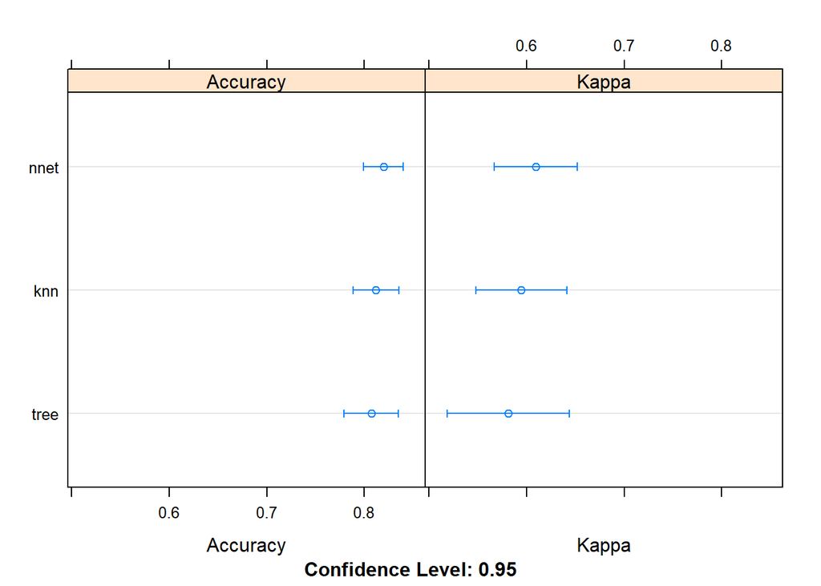

```r
dotplot(results)
```

4. Create a box plot to compare models

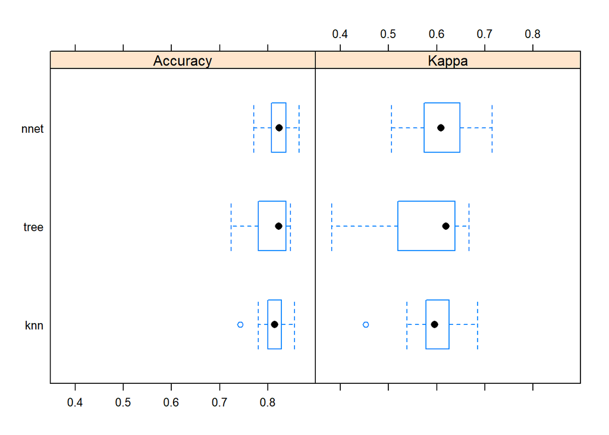

```r
bwplot(results)
```

5. Create a density plot to compare models

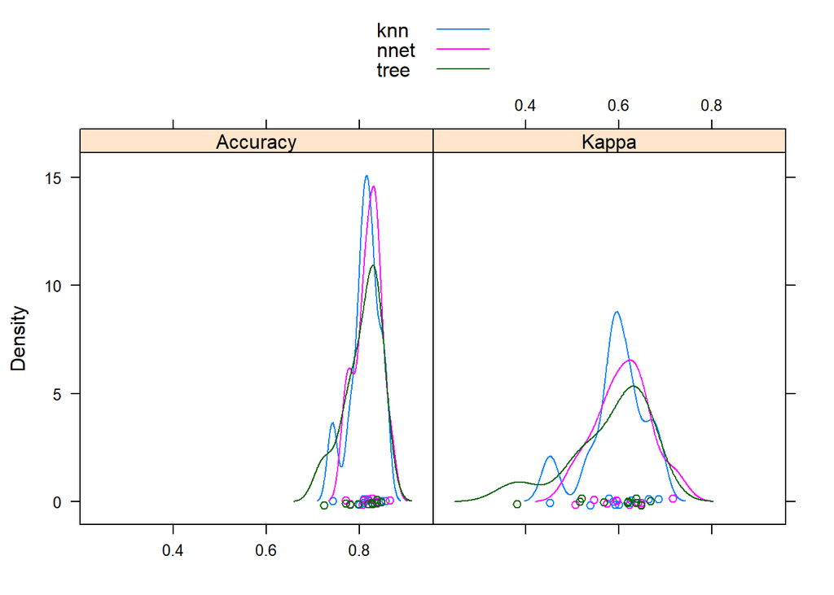

```r
densityplot(results, auto.key = TRUE)
```

6. Question: Which model would you choose? Why?

### 7. Deploy the Model

1. Determine the likelihood that Jack survives the Titanic.

```r
predict(
  object = neuralModel,
  newdata = data.frame(
    Class = 3,
    Sex = "male",
    Age = 20,
    Family = 1),
  type = "prob")
```

```
##          No       Yes
## 1 0.8598103 0.1401897
```

2. Question: Would you bet on Jack surviving?
3. Determine the likelihood that you would survive the Titanic.
4. Question: Would you take that bet?